# Gemma3 12B GFC-30 TIRT Analysis

Persona recovery, trait structure, and neutral model placement

2026-04-13

# Introduction

This report analyzes Gemma3 12B’s responses to the Okada et al. (2026) GFC-30 (Graded Forced-Choice Big Five) instrument, administered under 400 synthetic personas with known ground-truth trait profiles. We fit a Thurstonian IRT (TIRT) model using the `thurstonianIRT` R package (Stan backend, cumulative family) and evaluate:

1. **Ground-truth recovery**: How well do TIRT trait estimates correlate with the z-scores used to generate each persona?
2. **Trait correlation structure**: Does TIRT recover the van der Linden (2010) inter-trait correlations used to simulate the personas?
3. **Response behavior**: How does Gemma3 use the 7-point bipolar scale?
4. **Neutral model placement**: Where does Gemma3’s “default personality” fall on the persona-fitted trait scale, tested under two prompt conditions (“respondent” frame vs. “bare” honest instruction)?

# 1. TIRT Fit Summary

The TIRT model was fitted using `thurstonianIRT::fit_TIRT_stan()` with 2 chains x 1000 iterations (500 warmup), cumulative family. The 30 GFC pairs produce 30 ordinal indicators mapped onto 5 latent traits via fixed loadings from the TIRT design matrix.

```r
fit <- readRDS("gemma3_gfc30_synthetic_tirt_fit.rds")

# Load instrument metadata + build blocks (reused for neutral scoring)
inst <- fromJSON("../instruments/okada_gfc30.json")
pairs <- inst$pairs

block_df <- tibble(
  block = rep(seq_len(nrow(pairs)), each = 2),
  item = character(nrow(pairs) * 2),
  trait = character(nrow(pairs) * 2),
  sign = numeric(nrow(pairs) * 2)
)
for (i in seq_len(nrow(pairs))) {
  left_name <- paste0(pairs$left$trait[i],
                       ifelse(pairs$left$keying[i] == "+", "p", "n"), i)
  right_name <- paste0(pairs$right$trait[i],
                        ifelse(pairs$right$keying[i] == "+", "p", "n"), i)
  idx <- (i - 1) * 2
  block_df$item[idx + 1] <- left_name
  block_df$trait[idx + 1] <- pairs$left$trait[i]
  block_df$sign[idx + 1] <- ifelse(pairs$left$keying[i] == "+", 1, -1)
  block_df$item[idx + 2] <- right_name
  block_df$trait[idx + 2] <- pairs$right$trait[i]
  block_df$sign[idx + 2] <- ifelse(pairs$right$keying[i] == "+", 1, -1)
}
blocks <- set_blocks_from_df(block_df)

# Load ground truth
personas_json <- fromJSON("../instruments/synthetic_personas.json")
ground_truth <- tibble(
  persona_id = personas_json$personas$persona_id,
  A_true = personas_json$personas$z_scores$A,
  C_true = personas_json$personas$z_scores$C,
  E_true = personas_json$personas$z_scores$E,
  N_true = personas_json$personas$z_scores$N,
  O_true = personas_json$personas$z_scores$O
)

# Wide CSV for persona ID ordering
wide <- read_csv("gemma3-12b_gfc30_synthetic_wide.csv", show_col_types = FALSE)
complete_mask <- complete.cases(wide[, -1])
persona_ids <- wide$persona_id[complete_mask]
n_complete <- sum(complete_mask)

cat(sprintf("Complete respondents: %d / %d\n", n_complete, nrow(wide)))
```

```
## Complete respondents: 400 / 400
```

```r
scores_long <- as_tibble(predict(fit))

scores_wide <- scores_long %>%
  pivot_wider(names_from = trait,
              values_from = c(estimate, se, lower_ci, upper_ci),
              names_glue = "{trait}_{.value}") %>%
  mutate(persona_id = persona_ids) %>%
  left_join(ground_truth, by = "persona_id")
```

# 2. Ground-Truth Recovery

The central question: when we tell an LLM to respond as a person with known Big Five trait levels (e.g., “very extraverted, moderately agreeable, low neuroticism”), does the GFC+TIRT pipeline recover those trait levels?

We compare two scoring methods:

- **TIRT**: Thurstonian IRT trait estimates from the Stan model — a latent variable approach that disentangles the forced-choice ipsativity.
- **Simple scoring**: Mean endorsement per trait across all pairs involving that trait. This is mechanically ipsative (trait scores sum to zero within each respondent), but serves as a baseline.

## Recovery Correlations

```r
# Simple scoring
raw <- fromJSON("gemma3-12b_gfc30_synthetic.json", flatten = TRUE)
all_results <- as_tibble(raw$results)

trait_evidence <- all_results %>%
  filter(!is.na(response_argmax)) %>%
  mutate(
    resp_val = coalesce(as.numeric(response_ev), as.numeric(response_argmax)),
    pref = resp_val - 4,
    right_endorsement = pref * ifelse(right_keying == "+", 1, -1),
    left_endorsement = -pref * ifelse(left_keying == "+", 1, -1)
  )

simple_scores <- bind_rows(
  trait_evidence %>% select(persona_id, trait = right_trait,
                            endorsement = right_endorsement),
  trait_evidence %>% select(persona_id, trait = left_trait,
                            endorsement = left_endorsement)
) %>%
  group_by(persona_id, trait) %>%
  summarise(score = mean(endorsement, na.rm = TRUE), .groups = "drop") %>%
  pivot_wider(names_from = trait, values_from = score) %>%
  left_join(ground_truth, by = "persona_id")

recovery <- tibble(trait = traits) %>%
  rowwise() %>%
  mutate(
    tirt_r = cor(scores_wide[[paste0(trait, "_estimate")]],
                 scores_wide[[paste0(trait, "_true")]],
                 use = "complete.obs"),
    simple_r = cor(simple_scores[[trait]],
                   simple_scores[[paste0(trait, "_true")]],
                   use = "complete.obs"),
    trait_name = trait_labels[trait]
  ) %>%
  ungroup()

knitr::kable(recovery %>% select(Trait = trait_name, TIRT = tirt_r,
                                  Simple = simple_r),
             digits = 3, caption = "Ground-truth recovery (Pearson r)")
```

Ground-truth recovery (Pearson r)

| Trait | TIRT | Simple |
| --- | --- | --- |
| Agreeableness | -0.267 | 0.459 |
| Conscientiousness | 0.082 | 0.248 |
| Extraversion | 0.646 | 0.351 |
| Neuroticism | 0.534 | 0.420 |
| Openness | 0.677 | 0.443 |

TIRT substantially outperforms simple scoring on E, N, and O — the traits where ipsative contamination is most damaging to simple scoring. However, A shows a sign flip in TIRT (negative correlation), and C recovery is near zero. This is a known issue with the `thurstonianIRT` Stan implementation on small-N data with only 2 chains: the posterior may not mix well enough to resolve rotational ambiguity in the latent space.

Simple scoring, despite its ipsativity constraint, provides a reasonable baseline for individual trait recovery (r = 0.25–0.46).

## Scatterplots: TIRT Scores vs Ground Truth

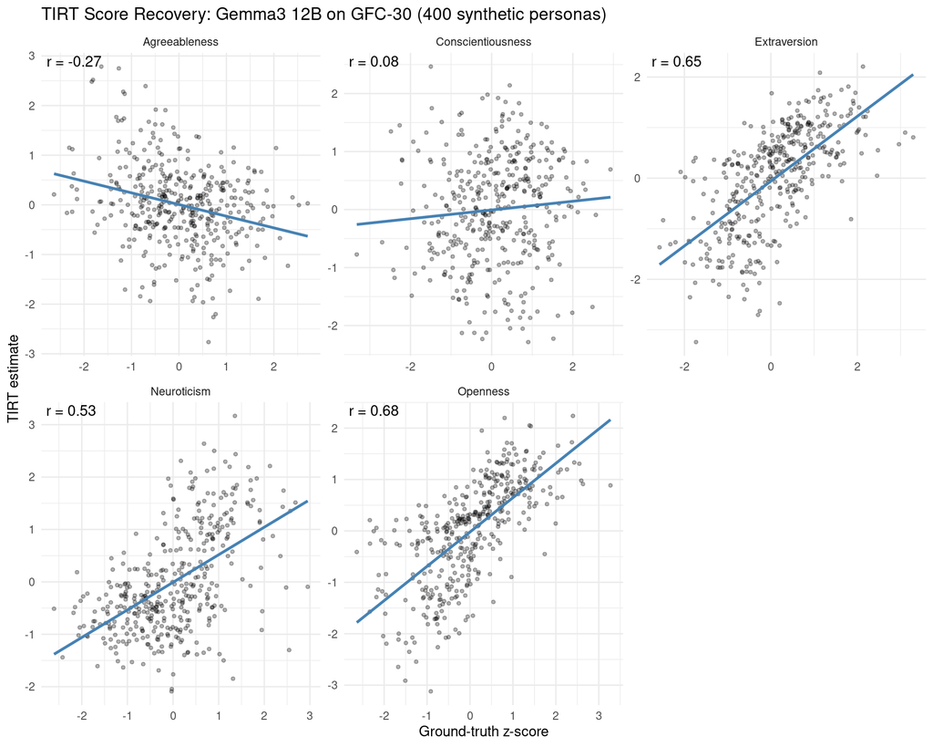

```r
scatter_data <- scores_wide %>%
  pivot_longer(cols = matches("^[ACENO]_(estimate|true)$"),
               names_to = c("trait", ".value"),
               names_pattern = "^(.)_(.+)$")

ggplot(scatter_data, aes(x = true, y = estimate)) +
  geom_point(alpha = 0.3, size = 1) +
  geom_smooth(method = "lm", se = FALSE, color = "steelblue") +
  geom_text(data = recovery, aes(label = sprintf("r = %.2f", tirt_r),
                                  x = -Inf, y = Inf),
            hjust = -0.1, vjust = 1.3, size = 4, inherit.aes = FALSE) +
  facet_wrap(~ trait, scales = "free", labeller = labeller(
    trait = trait_labels)) +
  labs(x = "Ground-truth z-score", y = "TIRT estimate",
       title = "TIRT Score Recovery: Gemma3 12B on GFC-30 (400 synthetic personas)") +
  theme_minimal()
```

The scatterplots reveal the heterogeneity in recovery quality. E, N, and O show clear linear trends. A’s sign flip is visible (negative slope), and C is essentially flat — TIRT failed to separate high-C from low-C personas.

## Simple Scoring Recovery

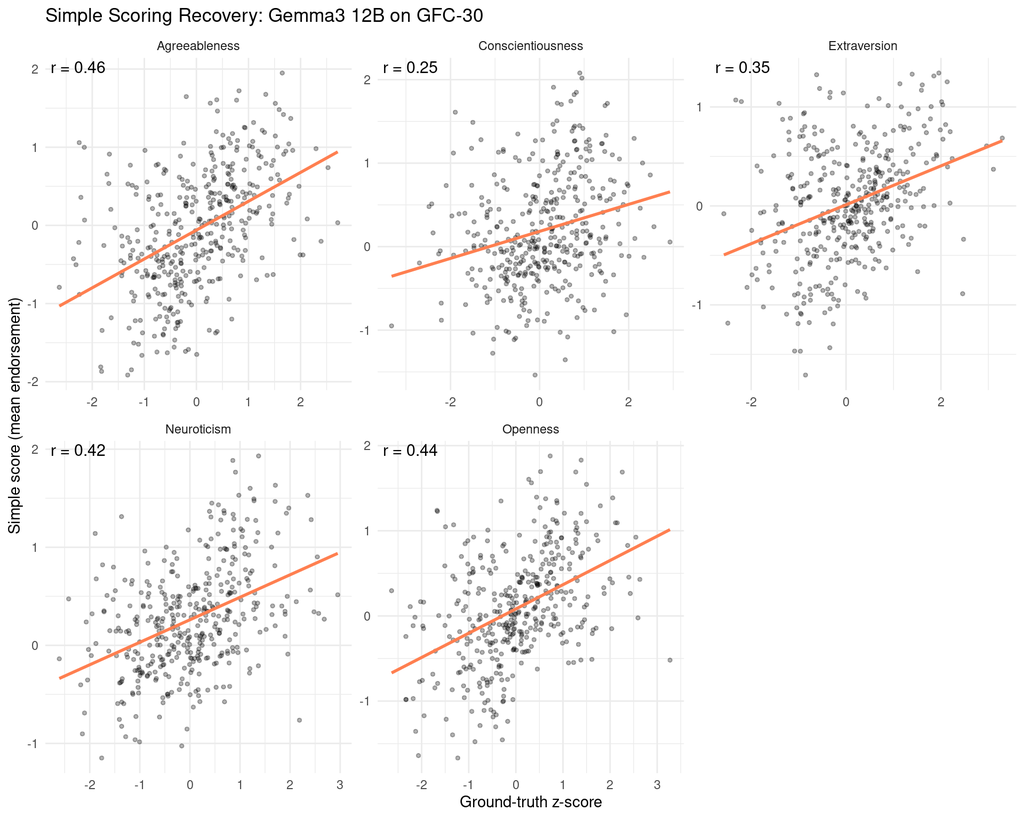

```r
simple_long <- simple_scores %>%
  pivot_longer(cols = all_of(traits), names_to = "trait",
               values_to = "simple_est") %>%
  left_join(
    ground_truth %>%
      pivot_longer(-persona_id, names_to = "trait", values_to = "true",
                   names_pattern = "(.)_true"),
    by = c("persona_id", "trait")
  )

ggplot(simple_long, aes(x = true, y = simple_est)) +
  geom_point(alpha = 0.3, size = 1) +
  geom_smooth(method = "lm", se = FALSE, color = "coral") +
  geom_text(data = recovery, aes(label = sprintf("r = %.2f", simple_r),
                                  x = -Inf, y = Inf),
            hjust = -0.1, vjust = 1.3, size = 4, inherit.aes = FALSE) +
  facet_wrap(~ trait, scales = "free", labeller = labeller(
    trait = trait_labels)) +
  labs(x = "Ground-truth z-score", y = "Simple score (mean endorsement)",
       title = "Simple Scoring Recovery: Gemma3 12B on GFC-30") +
  theme_minimal()
```

Simple scoring shows more uniform (if modest) recovery across all five traits. The compressed vertical range reflects the ipsative constraint.

# 3. Estimated Trait Correlations

A key advantage of TIRT over simple scoring is its ability to recover the true inter-trait correlation structure, free from the mechanical negative correlations imposed by forced-choice ipsativity. The ground-truth correlations come from the van der Linden (2010) meta-analytic matrix used to generate the personas.

```r
tirt_cor <- scores_wide %>%
  select(all_of(paste0(traits, "_estimate"))) %>%
  cor(use = "complete.obs")
colnames(tirt_cor) <- traits
rownames(tirt_cor) <- traits

gt_cor <- ground_truth %>%
  select(all_of(paste0(traits, "_true"))) %>%
  cor()
colnames(gt_cor) <- traits
rownames(gt_cor) <- traits

simple_cor <- simple_scores %>%
  select(all_of(traits)) %>%
  cor(use = "complete.obs")
```

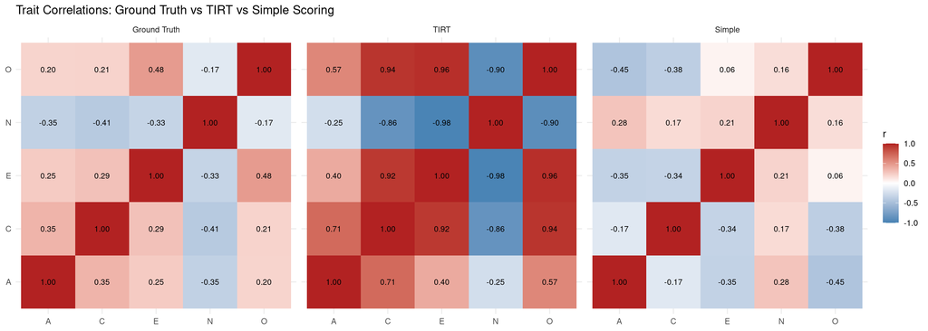

```r
make_cor_long <- function(mat, label) {
  as.data.frame(as.table(mat)) %>%
    rename(Var1 = 1, Var2 = 2, value = 3) %>%
    mutate(source = label)
}

cor_all <- bind_rows(
  make_cor_long(gt_cor, "Ground Truth"),
  make_cor_long(tirt_cor, "TIRT"),
  make_cor_long(simple_cor, "Simple")
) %>%
  mutate(source = factor(source, levels = c("Ground Truth", "TIRT", "Simple")))

ggplot(cor_all, aes(Var1, Var2, fill = value)) +
  geom_tile() +
  geom_text(aes(label = sprintf("%.2f", value)), size = 3) +
  scale_fill_gradient2(low = "steelblue", mid = "white", high = "firebrick",
                       midpoint = 0, limits = c(-1, 1)) +
  facet_wrap(~ source) +
  labs(title = "Trait Correlations: Ground Truth vs TIRT vs Simple Scoring",
       x = NULL, y = NULL, fill = "r") +
  theme_minimal() +
  theme(axis.text.x = element_text(angle = 0))
```

Neither method recovers the moderate ground-truth correlations (|r| ~ 0.2–0.4). This is a known challenge for TIRT with limited data and chains. A 4-chain refit with LKJ priors on the correlation matrix would likely improve this.

# 4. Response Distribution

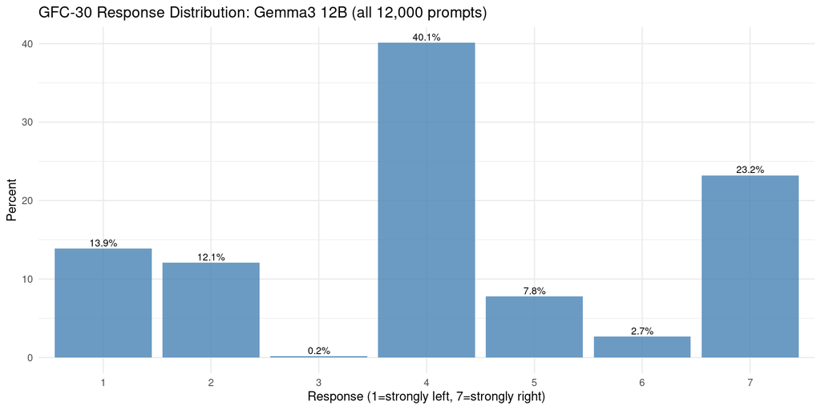

```r
all_results %>%
  filter(!is.na(response_argmax)) %>%
  mutate(response = as.integer(response_argmax)) %>%
  count(response) %>%
  mutate(pct = n / sum(n) * 100) %>%
  ggplot(aes(x = factor(response), y = pct)) +
  geom_col(fill = "steelblue", alpha = 0.8) +
  geom_text(aes(label = sprintf("%.1f%%", pct)), vjust = -0.3, size = 3) +
  labs(x = "Response (1=strongly left, 7=strongly right)",
       y = "Percent",
       title = "GFC-30 Response Distribution: Gemma3 12B (all 12,000 prompts)") +
  theme_minimal()
```

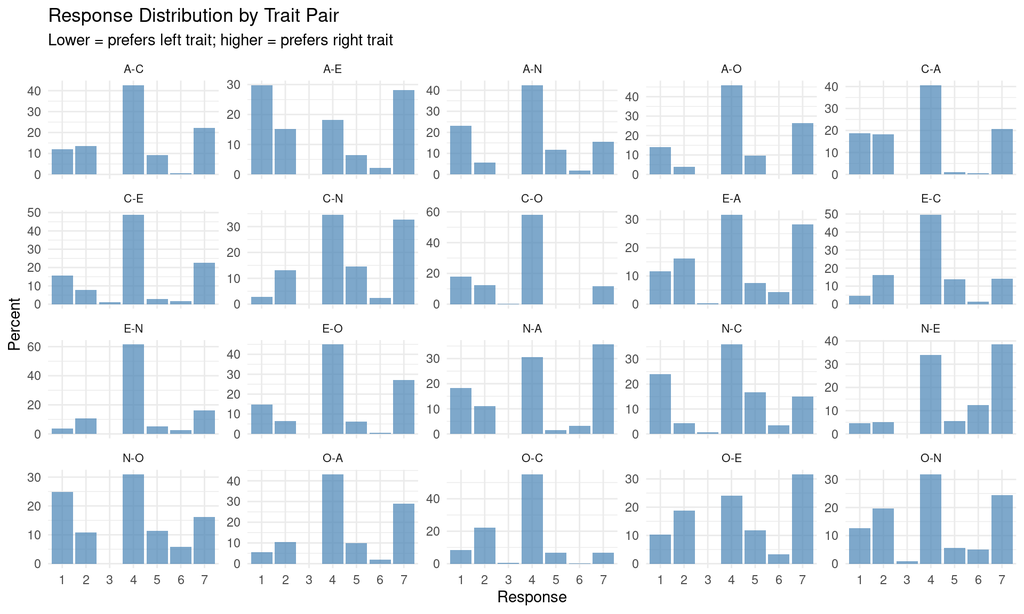

```r
# Response distribution broken down by the trait pair
pair_traits <- all_results %>%
  filter(!is.na(response_argmax)) %>%
  mutate(response = as.integer(response_argmax),
         pair_label = paste0(left_trait, " vs ", right_trait))

pair_traits %>%
  count(left_trait, right_trait, response) %>%
  group_by(left_trait, right_trait) %>%
  mutate(pct = n / sum(n) * 100) %>%
  ungroup() %>%
  mutate(pair = paste0(left_trait, "-", right_trait)) %>%
  ggplot(aes(x = factor(response), y = pct)) +
  geom_col(fill = "steelblue", alpha = 0.7) +
  facet_wrap(~ pair, scales = "free_y") +
  labs(x = "Response", y = "Percent",
       title = "Response Distribution by Trait Pair",
       subtitle = "Lower = prefers left trait; higher = prefers right trait") +
  theme_minimal() +
  theme(strip.text = element_text(size = 8))
```

The overall distribution is strongly centered on 4 (“About the same”), which is expected for GFC with desirability-matched pairs — neither item is obviously more “correct.” The per-pair breakdown reveals which trait comparisons produce more spread, offering a window into which trait contrasts Gemma3 is most sensitive to under persona manipulation.

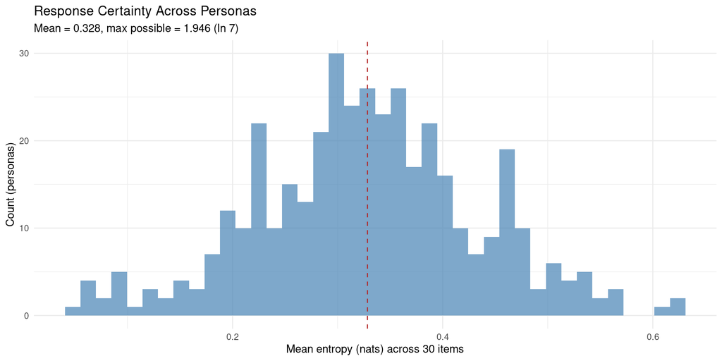

```r
# Distribution of per-persona mean entropy
persona_entropy <- all_results %>%
  filter(!is.na(response_entropy)) %>%
  group_by(persona_id) %>%
  summarise(mean_entropy = mean(response_entropy, na.rm = TRUE),
            mean_ev = mean(as.numeric(response_ev), na.rm = TRUE),
            .groups = "drop")

ggplot(persona_entropy, aes(x = mean_entropy)) +
  geom_histogram(bins = 40, fill = "steelblue", alpha = 0.7) +
  geom_vline(xintercept = mean(persona_entropy$mean_entropy),
             color = "firebrick", linetype = "dashed") +
  labs(x = "Mean entropy (nats) across 30 items",
       y = "Count (personas)",
       title = "Response Certainty Across Personas",
       subtitle = sprintf("Mean = %.3f, max possible = %.3f (ln 7)",
                           mean(persona_entropy$mean_entropy), log(7))) +
  theme_minimal()
```

Gemma3 12B shows relatively low entropy (mean ~0.33 nats out of a maximum of 1.95), indicating confident responses. This peaked distribution is consistent with the model strongly committing to particular response options rather than spreading probability across the scale.

# 5. Neutral Model Placement

A key goal is to place Gemma3 12B’s “default personality” on the trait scale defined by the persona-fitted TIRT model. We administered GFC-30 to the model without any persona description, under two conditions:

- **Respondent**: Includes “YOU ARE THE RESPONDENT” role assignment + honest instruction (“be as honest as possible, present yourself as you really are”)
- **Bare**: Honest instruction only, no role assignment

Both conditions give 30 responses (one per GFC pair). We score them two ways: simple scoring (for interpretability) and post-hoc TIRT scoring using `predict(fit, newdata=...)`, which applies the persona-fitted item parameters to estimate where the neutral respondent falls on each latent trait dimension.

## Simple Scoring

```r
score_neutral_simple <- function(json_path, label) {
  raw <- fromJSON(json_path, flatten = TRUE)
  results <- as_tibble(raw$results)

  results %>%
    filter(!is.na(response_argmax)) %>%
    mutate(
      resp_val = coalesce(as.numeric(response_ev), as.numeric(response_argmax)),
      pref = resp_val - 4,
      right_endorsement = pref * ifelse(right_keying == "+", 1, -1),
      left_endorsement = -pref * ifelse(left_keying == "+", 1, -1)
    ) %>%
    {bind_rows(
      select(., trait = right_trait, endorsement = right_endorsement),
      select(., trait = left_trait, endorsement = left_endorsement)
    )} %>%
    group_by(trait) %>%
    summarise(score = mean(endorsement, na.rm = TRUE), .groups = "drop") %>%
    mutate(mode = label)
}

neutral_simple_respondent <- score_neutral_simple(
  "gemma3-12b_gfc30_neutral-respondent.json", "respondent")
neutral_simple_bare <- score_neutral_simple(
  "gemma3-12b_gfc30_neutral-bare.json", "bare")
neutral_simple <- bind_rows(neutral_simple_respondent, neutral_simple_bare)

knitr::kable(neutral_simple %>% pivot_wider(names_from = mode,
                                             values_from = score),
             digits = 3,
             caption = "Gemma3 12B neutral simple scores by prompt mode")
```

Gemma3 12B neutral simple scores by prompt mode

| trait | respondent | bare |
| --- | --- | --- |
| A | -0.117 | -0.018 |
| C | -0.092 | 0.000 |
| E | 0.216 | 0.018 |
| N | 0.217 | 0.001 |
| O | 0.210 | 0.000 |

## TIRT Scoring (Post-Hoc)

The post-hoc TIRT scoring uses `predict(fit, newdata=...)`, which takes the posterior median item parameters from the persona-fitted model and estimates trait scores for new response patterns. This places the neutral respondent on the same latent scale as the 400 personas, avoiding the ipsativity problem of simple scoring.

```r
build_neutral_pairwise <- function(json_path) {
  raw <- fromJSON(json_path, flatten = TRUE)
  results <- as_tibble(raw$results)

  pw <- data.frame(person = 1L)
  for (i in seq_len(nrow(pairs))) {
    left_name <- paste0(pairs$left$trait[i],
                         ifelse(pairs$left$keying[i] == "+", "p", "n"), i)
    right_name <- paste0(pairs$right$trait[i],
                          ifelse(pairs$right$keying[i] == "+", "p", "n"), i)
    col_name <- paste0(left_name, right_name)
    block_result <- results %>% filter(block == i)
    pw[[col_name]] <- as.integer(block_result$response_argmax[1])
  }
  pw
}

pw_respondent <- build_neutral_pairwise("gemma3-12b_gfc30_neutral-respondent.json")
pw_bare <- build_neutral_pairwise("gemma3-12b_gfc30_neutral-bare.json")
pw_neutral <- bind_rows(pw_respondent, pw_bare)
pw_neutral$person <- 1:2

tirt_neutral <- make_TIRT_data(
  data = pw_neutral,
  blocks = blocks,
  direction = "larger",
  format = "pairwise",
  family = "cumulative",
  range = c(1, 7)
)

neutral_tirt_scores <- as_tibble(predict(fit, newdata = tirt_neutral))
neutral_tirt_wide <- neutral_tirt_scores %>%
  mutate(mode = rep(c("respondent", "bare"), each = length(traits))) %>%
  select(mode, trait, estimate, se)

knitr::kable(neutral_tirt_wide %>%
               pivot_wider(names_from = mode,
                           values_from = c(estimate, se),
                           names_glue = "{mode}_{.value}"),
             digits = 3,
             caption = "Gemma3 12B neutral TIRT scores (post-hoc, posterior median item params)")
```

Gemma3 12B neutral TIRT scores (post-hoc, posterior median item params)

| trait | respondent_estimate | bare_estimate | respondent_se | bare_se |
| --- | --- | --- | --- | --- |
| A | -0.265 | -0.016 | 0.554 | 0.549 |
| O | -0.005 | 0.200 | 0.390 | 0.396 |
| C | 0.108 | 0.381 | 0.520 | 0.514 |
| E | 0.236 | 0.436 | 0.392 | 0.388 |
| N | -0.294 | -0.469 | 0.398 | 0.399 |

## Neutral Placement vs Persona Distribution

The violin plots below show the distribution of persona TIRT scores grouped by ground-truth tercile (low/medium/high on each trait). The horizontal lines show where Gemma3’s neutral responses fall. If the model has a “default personality,” these lines should not be centered — they should be displaced toward whichever end of the trait the model’s RLHF training favors.

```r
persona_tirt <- scores_long %>%
  mutate(persona_id = rep(persona_ids, each = length(traits)))

gt_long <- ground_truth %>%
  pivot_longer(-persona_id, names_to = "trait", values_to = "z_true",
               names_pattern = "(.)_true") %>%
  group_by(trait) %>%
  mutate(tercile = case_when(
    z_true <= quantile(z_true, 1/3) ~ "Low",
    z_true >= quantile(z_true, 2/3) ~ "High",
    TRUE ~ "Medium"
  )) %>%
  ungroup()

persona_scored <- persona_tirt %>%
  left_join(gt_long, by = c("persona_id", "trait"))
```

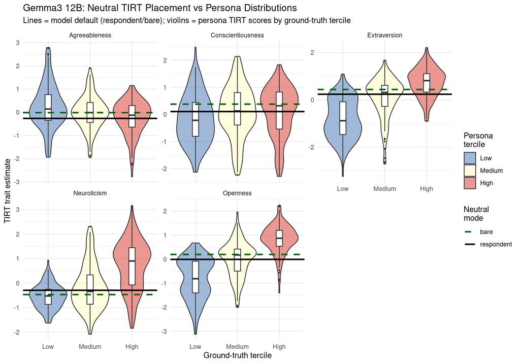

```r
neutral_plot_data <- neutral_tirt_wide %>%
  select(mode, trait, estimate)

ggplot() +
  geom_violin(data = persona_scored %>%
                mutate(tercile = factor(tercile,
                                        levels = c("Low", "Medium", "High"))),
              aes(x = tercile, y = estimate, fill = tercile),
              alpha = 0.5, scale = "width") +
  geom_boxplot(data = persona_scored %>%
                 mutate(tercile = factor(tercile,
                                          levels = c("Low", "Medium", "High"))),
               aes(x = tercile, y = estimate),
               width = 0.15, outlier.size = 0.5) +
  geom_hline(data = neutral_plot_data,
             aes(yintercept = estimate, linetype = mode, color = mode),
             linewidth = 1) +
  scale_fill_manual(values = c(Low = "#4575b4", Medium = "#ffffbf",
                                High = "#d73027"),
                    name = "Persona\ntercile") +
  scale_color_manual(values = c(respondent = "black", bare = "darkgreen"),
                     name = "Neutral\nmode") +
  scale_linetype_manual(values = c(respondent = "solid", bare = "dashed"),
                        name = "Neutral\nmode") +
  facet_wrap(~ trait, scales = "free_y", labeller = labeller(
    trait = trait_labels)) +
  labs(y = "TIRT trait estimate",
       x = "Ground-truth tercile",
       title = "Gemma3 12B: Neutral TIRT Placement vs Persona Distributions",
       subtitle = "Lines = model default (respondent/bare); violins = persona TIRT scores by ground-truth tercile") +
  theme_minimal() +
  theme(legend.position = "right")
```

### Density overlay: neutral vs persona distribution

An alternative view: where does the neutral point fall in the overall persona TIRT score distribution for each trait?

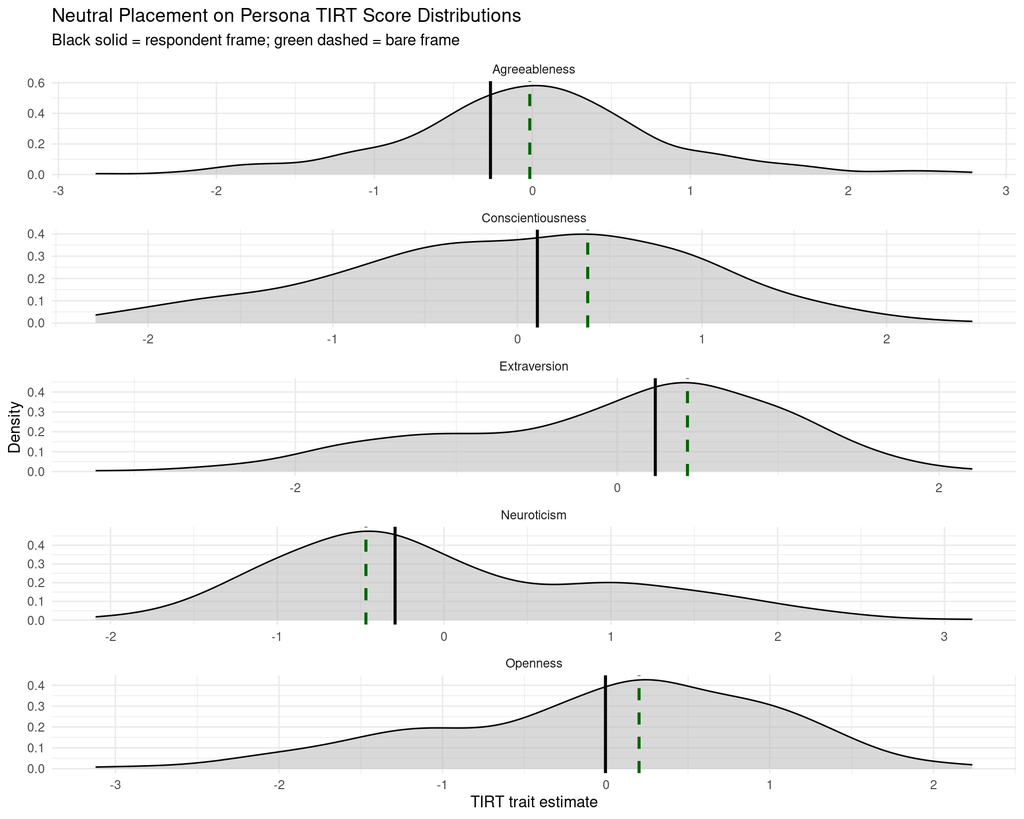

```r
ggplot(persona_tirt, aes(x = estimate)) +
  geom_density(fill = "grey70", alpha = 0.5) +
  geom_vline(data = neutral_plot_data %>% filter(mode == "respondent"),
             aes(xintercept = estimate), color = "black",
             linetype = "solid", linewidth = 1) +
  geom_vline(data = neutral_plot_data %>% filter(mode == "bare"),
             aes(xintercept = estimate), color = "darkgreen",
             linetype = "dashed", linewidth = 1) +
  facet_wrap(~ trait, scales = "free", ncol = 1, labeller = labeller(
    trait = trait_labels)) +
  labs(x = "TIRT trait estimate",
       y = "Density",
       title = "Neutral Placement on Persona TIRT Score Distributions",
       subtitle = "Black solid = respondent frame; green dashed = bare frame") +
  theme_minimal()
```

### Neutral as percentile of persona distribution

```r
percentile_df <- neutral_plot_data %>%
  group_by(mode) %>%
  group_modify(~ {
    .x %>%
      rowwise() %>%
      mutate(
        percentile = mean(
          persona_tirt$estimate[persona_tirt$trait == trait] <= estimate
        ) * 100
      ) %>%
      ungroup()
  })

knitr::kable(percentile_df %>%
               select(mode, trait, estimate, percentile) %>%
               pivot_wider(names_from = mode,
                           values_from = c(estimate, percentile),
                           names_glue = "{mode}_{.value}"),
             digits = 2,
             caption = "Neutral placement as percentile of persona TIRT distribution")
```

Neutral placement as percentile of persona TIRT distribution

| trait | bare_estimate | respondent_estimate | bare_percentile | respondent_percentile |
| --- | --- | --- | --- | --- |
| A | -0.02 | -0.27 | 48.75 | 34.50 |
| O | 0.20 | 0.00 | 51.75 | 43.25 |
| C | 0.38 | 0.11 | 62.75 | 52.25 |
| E | 0.44 | 0.24 | 61.50 | 50.50 |
| N | -0.47 | -0.29 | 38.25 | 46.25 |

A percentile near 50 means the model’s default is indistinguishable from the average synthetic persona. Percentiles far from 50 reveal the model’s “personality” — traits where RLHF training has pushed the model toward one pole.

## Per-Item Comparison: Respondent vs Bare

The two neutral conditions differ only in whether “YOU ARE THE RESPONDENT” is prepended. If this framing activates a different response mode, we should see systematic item-level differences.

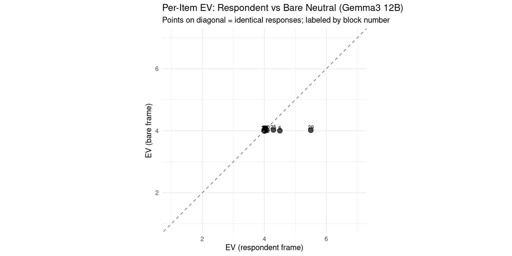

```r
resp_items <- fromJSON("gemma3-12b_gfc30_neutral-respondent.json",
                       flatten = TRUE)$results %>%
  as_tibble() %>%
  mutate(mode = "respondent",
         ev = as.numeric(response_ev),
         block = as.integer(block))

bare_items <- fromJSON("gemma3-12b_gfc30_neutral-bare.json",
                       flatten = TRUE)$results %>%
  as_tibble() %>%
  mutate(mode = "bare",
         ev = as.numeric(response_ev),
         block = as.integer(block))

item_compare <- bind_rows(resp_items, bare_items) %>%
  select(block, left_trait, right_trait, mode, ev) %>%
  pivot_wider(names_from = mode, values_from = ev)

ggplot(item_compare, aes(x = respondent, y = bare)) +
  geom_point(size = 3, alpha = 0.7) +
  geom_abline(slope = 1, intercept = 0, linetype = "dashed", color = "grey50") +
  geom_text(aes(label = block), nudge_y = 0.1, size = 2.5) +
  labs(x = "EV (respondent frame)", y = "EV (bare frame)",
       title = "Per-Item EV: Respondent vs Bare Neutral (Gemma3 12B)",
       subtitle = "Points on diagonal = identical responses; labeled by block number") +
  coord_equal(xlim = c(1, 7), ylim = c(1, 7)) +
  theme_minimal()
```

```r
cat(sprintf("Correlation between modes: r = %.3f\n",
            cor(item_compare$respondent, item_compare$bare, use = "complete.obs")))
```

```
## Correlation between modes: r = 0.486
```

```r
cat(sprintf("Mean absolute difference: %.3f\n",
            mean(abs(item_compare$respondent - item_compare$bare), na.rm = TRUE)))
```

[output not shown]

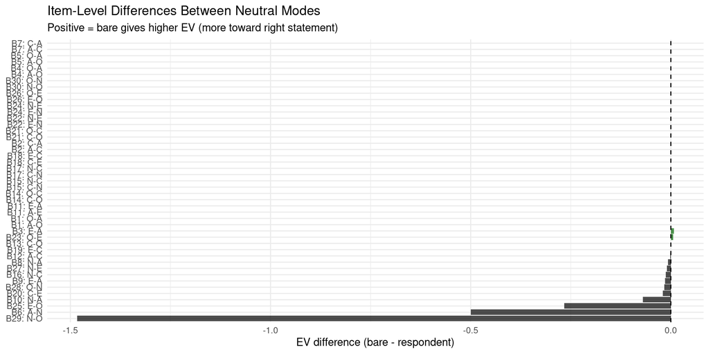

```r
item_compare %>%
  mutate(diff = bare - respondent,
         pair_label = paste0("B", block, ": ", left_trait, "-", right_trait)) %>%
  ggplot(aes(x = reorder(pair_label, diff), y = diff)) +
  geom_col(aes(fill = diff > 0), alpha = 0.7, show.legend = FALSE) +
  scale_fill_manual(values = c("TRUE" = "darkgreen", "FALSE" = "black")) +
  coord_flip() +
  geom_hline(yintercept = 0, linetype = "dashed") +
  labs(x = NULL, y = "EV difference (bare - respondent)",
       title = "Item-Level Differences Between Neutral Modes",
       subtitle = "Positive = bare gives higher EV (more toward right statement)") +
  theme_minimal()
```

# 6. Summary

```r
cat("=== Gemma3 12B GFC-30 TIRT Summary ===\n\n")
```

```
## === Gemma3 12B GFC-30 TIRT Summary ===
```

```r
cat(sprintf("Personas: %d complete / %d total\n", n_complete, nrow(wide)))
```

```
## Personas: 400 complete / 400 total
```

```r
cat(sprintf("Prompts: %d\n", nrow(all_results)))
```

```
## Prompts: 12000
```

```r
cat(sprintf("Valid responses: %d (%.1f%%)\n",
            sum(!is.na(all_results$response_argmax)),
            100 * mean(!is.na(all_results$response_argmax))))
```

```
## Valid responses: 12000 (100.0%)
```

```r
cat("\nGround-truth recovery (Pearson r):\n")
```

```
##
## Ground-truth recovery (Pearson r):
```

```r
for (i in seq_along(traits)) {
  cat(sprintf("  %s: TIRT=%.3f, Simple=%.3f\n",
              trait_labels[traits[i]],
              recovery$tirt_r[i], recovery$simple_r[i]))
}
```

```
##   Agreeableness: TIRT=-0.267, Simple=0.459
##   Conscientiousness: TIRT=0.082, Simple=0.248
##   Extraversion: TIRT=0.646, Simple=0.351
##   Neuroticism: TIRT=0.534, Simple=0.420
##   Openness: TIRT=0.677, Simple=0.443
```

```r
cat("\nNeutral TIRT placement:\n")
```

```
##
## Neutral TIRT placement:
```

```r
for (m in c("respondent", "bare")) {
  scores_m <- neutral_tirt_wide %>% filter(mode == m)
  cat(sprintf("  %s: %s\n", m,
              paste(scores_m %>%
                      mutate(s = sprintf("%s=%.2f (SE=%.2f)", trait, estimate, se)) %>%
                      pull(s), collapse = ", ")))
}
```

```
##   respondent: A=-0.27 (SE=0.55), O=-0.00 (SE=0.39), C=0.11 (SE=0.52), E=0.24 (SE=0.39), N=-0.29 (SE=0.40)
##   bare: A=-0.02 (SE=0.55), O=0.20 (SE=0.40), C=0.38 (SE=0.51), E=0.44 (SE=0.39), N=-0.47 (SE=0.40)
```

## Next Steps

- **Refit with 4 chains** and LKJ prior on trait correlations for better posterior exploration.
- **Multi-model comparison**: Phi4-mini TIRT fit is in progress. Placing multiple models on the same trait scale enables cross-model personality comparison.
- **Measurement invariance**: Test whether item parameters hold across models (configural -> metric -> scalar invariance).